# Reproducible pitch for shiny app

C. Roelofs

28 juli 2017

# R Markdown presentation on a Shiny app

# Basic description

The app shows some basic stuff that can be done in Shiny. It features three tab panels which have different sidepanels.

- On the first page there is a welcome text and some documentation about how to use the app.
- On the second panel you van fit some data to a linear model. You can add extra features to take into account using the group check box input. The plot shows the data and the result.
- The third panel shows the data. It is possible to download the dataset as well.

# Data set mtcars

The app uses the mtcars dataset. The data was extracted from the 1974 Motor Trend US magazine, and comprises fuel consumption and 10 aspects of automobile design and performance for 32 automobiles (1973-74 models).

```r
data(mtcars)
summary(mtcars[c('mpg','hp','wt','qsec')])
```

```
##       mpg              hp              wt             qsec
##  Min.   :10.40   Min.   : 52.0   Min.   :1.513   Min.   :14.50
##  1st Qu.:15.43   1st Qu.: 96.5   1st Qu.:2.581   1st Qu.:16.89
##  Median :19.20   Median :123.0   Median :3.325   Median :17.71
##  Mean   :20.09   Mean   :146.7   Mean   :3.217   Mean   :17.85
##  3rd Qu.:22.80   3rd Qu.:180.0   3rd Qu.:3.610   3rd Qu.:18.90
##  Max.   :33.90   Max.   :335.0   Max.   :5.424   Max.   :22.90
```

# Plots and prediction of miles per gallon

Basic output of the second panel is a prediction of miles per gallon based on the horse power of a car:

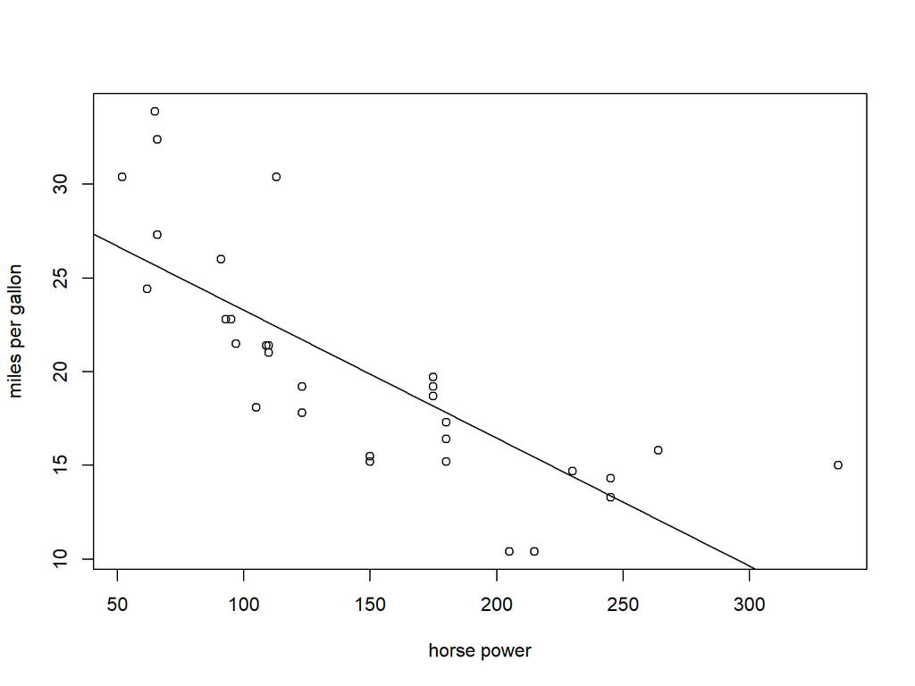

# Shiny also features a download button !

On the last panel you can filter the data to find out what you’re looking at, but it is also possible to download some data. This is done using a ‘downloadHandler’ on the server side of the application and a ‘downloadButton’ on the user interface.